# Klotho QC

Anna L Tyler

January 11, 2025

The purpose of this document is to run some QC on the Klotho data. In particular, we look for sample swaps in the RNA seq data.

This workflow uses data from all animals generated by 1.Klotho_Initial_Data_Visualization.Rmd. If it finds examples of sample swaps, it writes out an alternative animal information table that can be used in any workflow as an alternative to the original table.

```r
rm(list = ls())

library(here)

processed.data.dir <- here("Results", "all")
results.dir <- here("Results", "QC")

all.fun <- list.files(here("Code"), full.names = TRUE)
for(i in 1:length(all.fun)){source(all.fun[i])}
```

```r
needed.libraries <- c("gprofiler2", "DT", "igraph")
load_libraries(needed.libraries)
```

```r
count.data <- read.delim(here("Data", "Mouse", "rsem.merged.gene_counts.tsv"))
condensed.table <- read.csv(file.path(processed.data.dir, "mouse.info.csv"))
diff.test <- readRDS(file.path(processed.data.dir, "gene_Effects_of_sex_climb.RDS"))
expr <- readRDS(file.path(processed.data.dir, "processed_data", "Scaled_Expression.RDS"))
```

We investigated the possibility of sample swaps using sex as an indicator. We used expression from female- and male- specific genes and compared their expression to the sex labels specified in the data from the animal room.

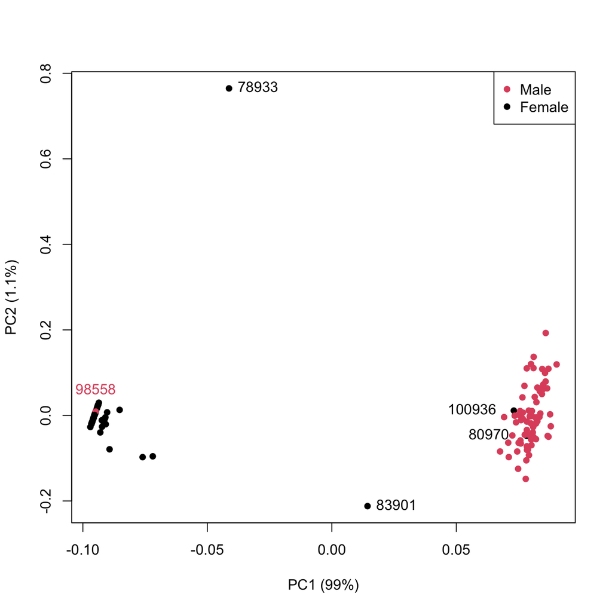

```r
y.genes <- c("Ddx3y", "Kdm5d", "Eif2s3y", "Uty")
y.id.table <- gconvert(y.genes, organism = "mmusculus", target = "ENSG")
y.gene.id <- y.id.table[,"target"]
names(y.gene.id)  <- y.id.table[,"name"]

x.genes <- "Xist"
x.id.table <- gconvert(x.genes, organism = "mmusculus", target = "ENSG")
x.gene.id <- x.id.table[,"target"]
names(x.gene.id)  <- x.id.table[,"name"]

x.gene.idx <- which(count.data[,"gene_id"] == x.gene.id[1])
x.gene.expr <- as.numeric(count.data[x.gene.idx,3:ncol(count.data)])

y.gene.idx <- which(count.data[,"gene_id"] %in% y.gene.id)
sex.expr <- count.data[c(y.gene.idx, x.gene.idx),3:ncol(count.data)]

#pheatmap(log2(sex.expr+1), cluster_rows = FALSE, cluster_cols = FALSE)
test <- plot.decomp(t(log2(sex.expr+1)), cols = as.numeric(as.factor(condensed.table[,"sex_climb"])))
legend("topright", col = c(2,1), legend = c("Male", "Female"), pch = 16)

min.pc1 <- -0.05; max.pc1 <- 0.05
not.grouped.idx <- intersect(which(test$u[,1] > min.pc1), which(test$u[,1] < max.pc1))
text(test$u[not.grouped.idx,1], test$u[not.grouped.idx,2],
  labels = gsub("X", "", colnames(sex.expr)[not.grouped.idx]), pos = 4)

mis.male <- intersect(which(test$u[,1] < -0.05), which(condensed.table[,"sex_climb"] == "Male"))
mis.female <- intersect(which(test$u[,1] > 0.05), which(condensed.table[,"sex_climb"] == "Female"))

text(test$u[mis.male,1], test$u[mis.male,2],
  labels = gsub("X", "", colnames(sex.expr)[mis.male]), pos = 3, offset = 1, col = 2)

text(test$u[mis.female,1], test$u[mis.female,2],
  labels = gsub("X", "", colnames(sex.expr)[mis.female]), pos = 2, offset = 1, col = 1)
```

```r
all.mis <- c(not.grouped.idx, mis.male, mis.female)
```

The following plots show Xist expression vs. expression of several genes on the Y chromosome. The animals identified above are labeled.

I hypothesize that animal 78933 is an XO female and that animal 83901 is an XXY male. The other three animals might have mislabeled RNA-Seq data.

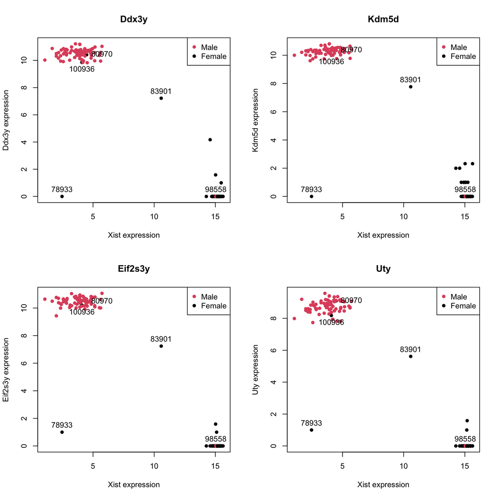

```r
par(mfrow = c(2,2))
for(i in 1:length(y.gene.id)){
  gene.name <- names(y.gene.id)[i]
  gene.idx <- which(count.data[,"gene_id"] == y.gene.id[i])
  gene.expr <- as.numeric(count.data[gene.idx,3:ncol(count.data)])

  expr.order <- order(gene.expr)
  climb.sex.col <- as.numeric(as.factor(condensed.table[,"sex_climb"]))

  plot(log2(x.gene.expr+1), log2(gene.expr+1), col = climb.sex.col, pch = 16, xlab = "Xist expression",
    ylab = paste(gene.name, "expression"), main = gene.name)
  legend("topright", col = c(2,1), legend = c("Male", "Female"), pch = 16)
  text(log2(x.gene.expr+1)[all.mis], log2(gene.expr+1)[all.mis],
    labels = gsub("X", "", colnames(sex.expr)[all.mis]), pos = c(3, 3, 3, 1, 4))
}
```

```r
datatable(condensed.table[all.mis,])
```

|  | animalName | sequencingBatch | climbID | sampleName | diet | age_d | age_m | validated.gt | sex_climb | sex_ge | validated.sex | seq_genotype | climb_geno |
| --- | --- | --- | --- | --- | --- | --- | --- | --- | --- | --- | --- | --- | --- |
| 16 | 78933 | 23-model-ad-002-run2 | 349102 | GT23-09804 | 6% Standard | 361 | 12 | TRUE | Female | Male | False | VS/VS | VS/VS |
| 58 | 83901 | 23-model-ad-002 | 353943 | GT23-09577 |  | 367 | 12 | TRUE | Female | Male | False | FC/FC | FC/FC |
| 130 | 98558 | 23-model-ad-002 | 379826 | GT23-09554 | 6% Standard | 112 | 4 | TRUE | Male | Female | False | WT/WT | VS/VS |
| 4 | 100936 | 23-model-ad-002 | 380289 | GT23-09552 |  | 108 | 4 | TRUE | Female | Male | False | VS/VS | WT/VS |
| 31 | 80970 | 23-model-ad-002 | 352430 | GT23-09549 | 6% Standard | 373 | 12 | TRUE | Female | Male | False | WT/WT | WT/FC |

```r
top.n <- 50
```

To further investigate the sex of these animals, we collected the top 50 genes that were differentially expressed by sex and performed a decomposition on the matrix. This does not include any genes on the Y chromosome, as these have been removed.

We still see three misclassified animals and two intermediate animals, although, appears more male in this setting, which is not consistent with an XO female. This really doesn’t help, does it?

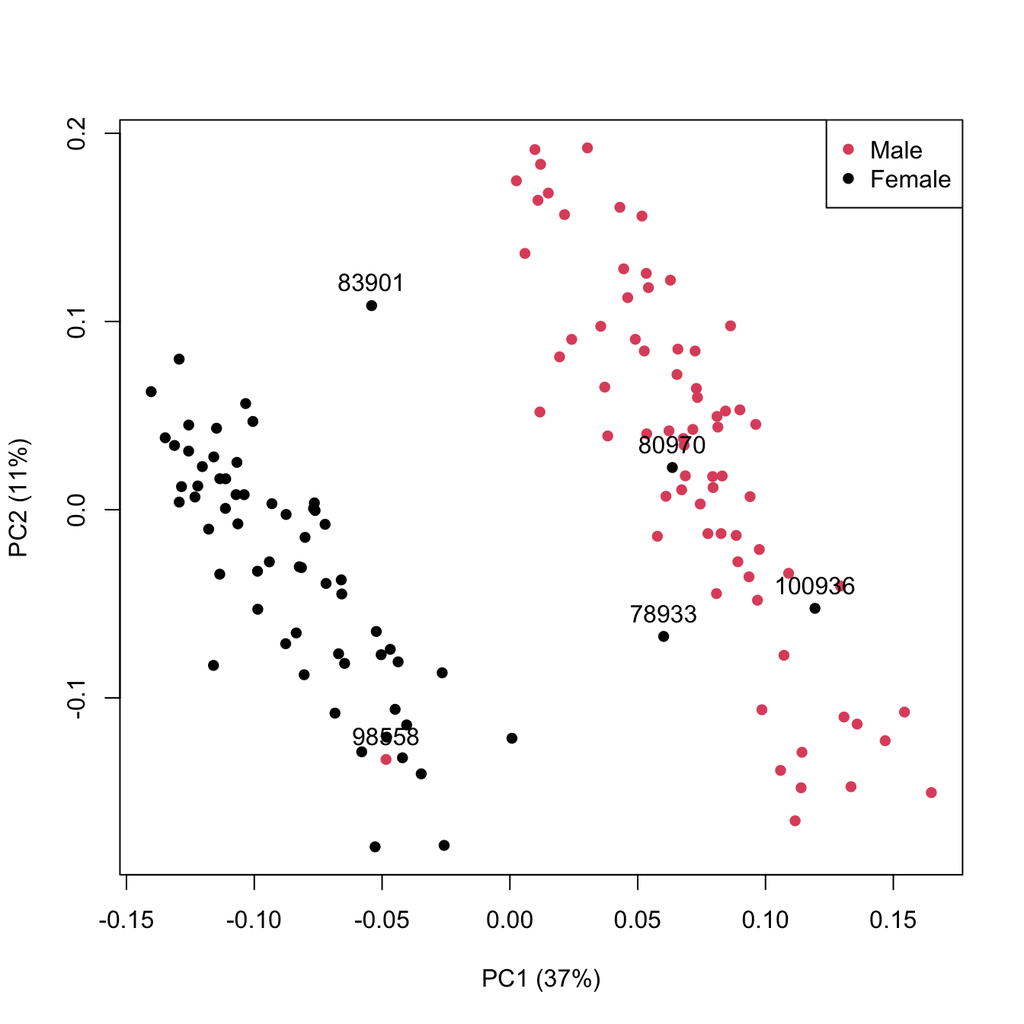

```r
#This code should be run with all animals (not an age cohort)
#we select genes that are most differentially expressed by a
#given factor and use those in the PC to maximize our ability
#to see mis-matched animals based on that factor

top.diff.idx <- order(diff.test$R2, decreasing = TRUE)[1:top.n]
pc <- plot.decomp(t(expr[top.diff.idx,]), cols = as.numeric(as.factor(condensed.table[,"sex_climb"])))
text(pc$u[all.mis,1], pc$u[all.mis,2], colnames(expr)[all.mis], pos = 3)
legend("topright", col = c(2,1), legend = c("Male", "Female"), pch = 16)
```

The next step is to look for obvious swaps. For each of the mismatched animals is there another mismatched animal for which the computational calls for the RNA-Seq sample and the climb calls are perfectly swapped?

I will use the condensed table to match computational calls and climb calls.

```r
#a function to check whether the computational calls of one animal
#match the climb calls of another animal
check_pairs <- function(animal1, animal2, sex_col1 = "sex_climb",
  sex_col2 = "sex_ge", geno_col1 = "climb_geno",
  geno_col2 = "seq_genotype", check_type = c("undirected", "directed")){

  check_type <- check_type[1] #default is undirected
  climb_sex1 <- animal1[sex_col1]
  comp_sex1 <- animal1[sex_col2]
  climb_geno1 <- animal1[geno_col1]
  comp_geno1 <- animal1[geno_col2]
  #climb_age1 <- animal1["age_m"]

  climb_sex2 <- animal2[sex_col1]
  comp_sex2 <- animal2[sex_col2]
  climb_geno2 <- animal2[geno_col1]
  comp_geno2 <- animal2[geno_col2]
  #climb_age2 <- animal2["age_m"]

    if(check_type == "undirected"){
        #animal 1 must match animal 2 and vice versa
        match_geno <- (comp_geno1 == climb_geno2) && (comp_geno2 == climb_geno1)
        match_sex <- (comp_sex1 == climb_sex2) && (comp_sex2 == climb_sex1)
    }else{
        #animal 1 must match animal 2, but doesn't need to match the other way
        match_geno <- (comp_geno1 == climb_geno2)
        match_sex <- (comp_sex1 == climb_sex2)
    }

  if(match_geno && match_sex){
    result <- 1
  }else{
    result <- 0
  }

  return(result)
}
```

```r
not.validated <- union(which(condensed.table[,"validated.sex"] == "FALSE"),
    which(condensed.table[,"validated.gt"] == "FALSE"))

sub.validate <- condensed.table[not.validated,]

animal.pairs <- pair.matrix(1:nrow(sub.validate))
possible.swaps <- rep(0, nrow(sub.validate))

for(i in 1:nrow(animal.pairs)){
    idx1 <- animal.pairs[i,1]
    idx2 <- animal.pairs[i,2]
    possible.swaps[i] <- check_pairs(animal1 = sub.validate[idx1,], animal2 = sub.validate[idx2,])
}

test.pairs <- animal.pairs[which(possible.swaps > 0),]
```

There were no animals among those that were not validated computationally that had an obvious swap.

The next thing to look at is whether there were not individual swaps, but some kind of rotation of samples. For examples, samples a, b, and c got put into slots b, c, and a, respectively. To check this, we look in a directed manner to see if there are any closed loops that for which the sequencing calls match the climb calls.

The graph below shows which animal sequence calls match the climb calls of another animal. There are no loops, so there is still no obvious way that the samples got mixed up.

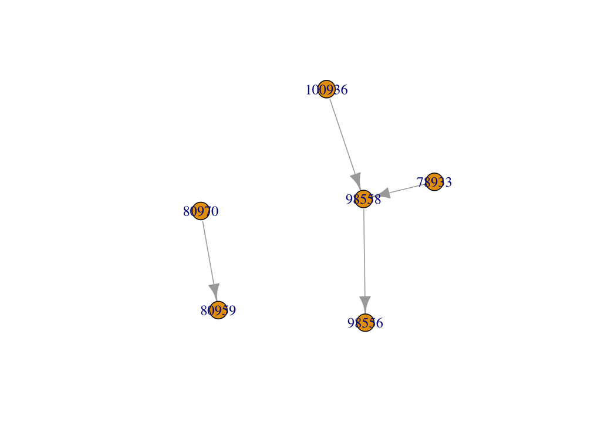

```r
possible.rotation <- rep(0, nrow(sub.validate))

for(i in 1:nrow(animal.pairs)){
    idx1 <- animal.pairs[i,1]
    idx2 <- animal.pairs[i,2]
    possible.rotation[i] <- check_pairs(animal1 = sub.validate[idx1,], animal2 = sub.validate[idx2,],
        check_type = "directed")
}

rotation.edges <- animal.pairs[which(possible.rotation > 0),]
swap_graph <- cbind(as.character(sub.validate[rotation.edges[,1], "animalName"]),
    as.character(sub.validate[rotation.edges[,2], "animalName"]))
rotation.net <- graph_from_edgelist(swap_graph)
plot(rotation.net)
```

Part of the difficulty here is that there are multiple replicates in a single sex-genotype group. If any swaps happened within a group, we would not be able to see it. And we can’t validate any of the other factors using sequencing, so we are stuck.